# Tutorial 6: Social Media Mining in Learning Contexts

Bodong Chen  
#LASI2018, June 11-13, NYC

### About Me

Assistant Professor in learning technologies  
University of Minnesota

- Collaborative learning
- Learning analytics
- MOOCs

### Housekeeping

- Github repository: https://github.com/meefen/lasi18-smm (bit.ly/lasi18smm)
  - `git clone` or Download ZIP
- Twitter hashtag: #LASI18smm
- Feel free to ask questions ANYTIME!

### Alternative

- CoLaboratory (check whether R works)
- Watson Studio

### Tentative Agenda

1. Social media basics
2. Social media for learning
3. Collecting social media data
4. Mining social media data

## Part 1: Social Media Basics

### What are social media?

1. Pair & Share (self-intro)
2. Tweet out your definition(s) – #LASI18smm

### What do social media researchers say?

Gruzd, Staves and Wilk 2012:

> Examples of social media include social network sites (e.g., Facebook); wikis (e.g., wikispaces); media-sharing services (e.g., YouTube); blogging tools (e.g., Blogger); micro-blogging services (e.g., Twitter); social bookmarking (e.g., Delicious); bibliographic management tools (e.g., Zotero); and presentation-sharing tools (e.g., Slideshare).

### What do social media researchers say?

Obar & Wildman, 2015:

1. Social media services are (currently) Web 2.0 Internet-based applications
2. User-generated content is the lifeblood of social media
3. Individuals and groups create user-specific profiles for a site or app designed and maintained by a social media service
4. Social media services facilitate the development of social networks online by connecting a profile with those of other individuals and/or groups

### Example: Twitter

[figure not shown]

(Goggins & Petakovic, 2014)

### Example: Github

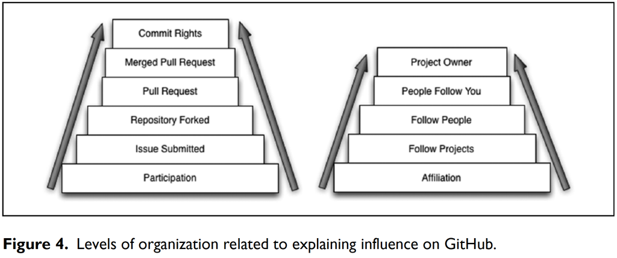

(Goggins & Petakovic, 2014)